# Threespine stickleback (*Gasterosteus aculeatus*) armor evolution

BIO 107

2023-02-13

# What’s due

1. The Google sheet submitted to Brightspace on or before Monday, Feb 6
2. A Google doc report submitted to Brightspace on or before Monday, Feb 13.

# Randomized Groups

```r
set.seed(yday(Sys.Date()))

thursday <- c("Ashburn Shalee", "Burch Kylah", "Burke Tim", "Champney Luke", "Chretien Cody", "Elliott Lydia", "Fitzgerald Ellis", "Fournier Daniel", "Ho Mandy", "Ilott Kadin", "Laing Chelsi", "Lattin Muriel", "Mahmoud Azraa", "Michaud Matthew", "Mohamad Dima", "Mohammad Negina", "Rivero Vanessa", "Roderick Mackenzie", "Strout Madison", "Walls Hailey")
friday <- c("Burnham Spencer", "Chandler Mack", "Kilby Lisa", "Muculu Eunice", "Nartey David", "Perry Lilith", "Roche Ciara", "Segovia Britany")


thu_rand <- data.table(
  Group = paste(rep(1:5, each = 4),": "),
  Student = sample(thursday))

fri_rand <- data.table(
  Group = paste(rep(1:4, each = 2),": "),
  Student = sample(friday))

kable(
  list(Thursday = thu_rand,
  friday = fri_rand)
) |>
  kable_styling(full_width = FALSE)
```

| Group | Student |
| --- | --- |
| 1 : | Rivero Vanessa |
| 1 : | Laing Chelsi |
| 1 : | Ashburn Shalee |
| 1 : | Walls Hailey |
| 2 : | Chretien Cody |
| 2 : | Roderick Mackenzie |
| 2 : | Ho Mandy |
| 2 : | Burch Kylah |
| 3 : | Fournier Daniel |
| 3 : | Elliott Lydia |
| 3 : | Ilott Kadin |
| 3 : | Lattin Muriel |
| 4 : | Mohammad Negina |
| 4 : | Mohamad Dima |
| 4 : | Fitzgerald Ellis |
| 4 : | Strout Madison |
| 5 : | Michaud Matthew |
| 5 : | Mahmoud Azraa |
| 5 : | Burke Tim |
| 5 : | Champney Luke |

| Group | Student |
| --- | --- |
| 1 : | Perry Lilith |
| 1 : | Roche Ciara |
| 2 : | Nartey David |
| 2 : | Segovia Britany |
| 3 : | Burnham Spencer |
| 3 : | Muculu Eunice |
| 4 : | Chandler Mack |
| 4 : | Kilby Lisa |

# We’re watching movies!

We will start class with 15 minute video [The Making of the Fittest: Evolving Switches, Evolving Bodies](https://www.biointeractive.org/classroom-resources/making-fittest-evolving-switches-evolving-bodies).

# Spreadsheet setup

The best practice of data setup and archiving for portability to colleagues and reproducibility of results is to organize data in **long format**. This simply means that all measures of a single variable are in a single column. You need to set up your data in long format.

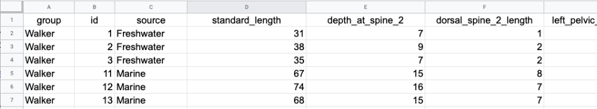

The image above shows a minimal example of long format. Note that

1. The measures of a single variable for both groups (freshwater and marine) are in the same column. This is long format.

# Measuring stickleback armor

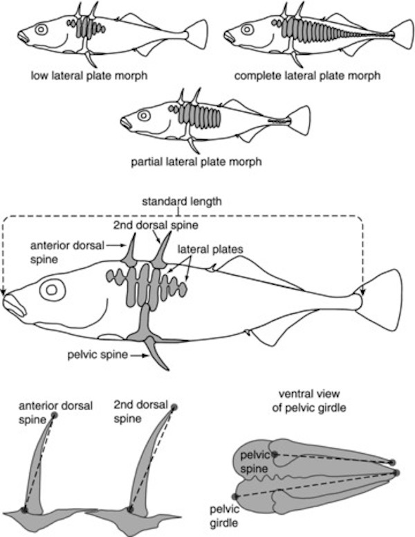

Table of measures. Use the Labels as column labes in Google Sheets.

| Measure | Label |
| --- | --- |
| standard length | standard_length |
| body depth at 2nd dorsal spine (but not including spine) | depth_at_spine_2 |
| 2nd dorsal spine length | dorsal_spine_2_length |
| left pelvic spine length | left_pelvic_spine_length |
| pelvic length | pelvic_length |
| left side lateral plate count | left_lateral_plate_count |

## If you are taking measurements from a caliper

use the caliper.

## If you are taking measurements from an image

[Download and install Fiji (a version of imageJ)](https://imagej.net/software/fiji/)

There should be two image files: 1) ten fish in lateral view, 2) ten fish in ventral view. These are the same fish in same order. It is important to digitize these in order!

Open the images

1. Move both images into a single folder that only includes these images
2. Open fiji app on computer
3. Go to menu item File > Import > Image sequence. Browse your computer and open the folder that contains the images
4. Click the right and left arrow keys to move through the stack of images (there should be only two, one lateral view and one ventral view). Start with the lateral view.

Set the image scale

5. Click the line tool on the tool palette (5th icon from left)
6. Click and drag a line between any two points on the ruler (an easy distance is helpful, example, make your line 5 cm long)
7. Go to menu item Analyze > Set Scale.
8. Click in the Known Distance text box. Type in the length of the line you created along the ruler in cm units.

For each fish in lateral view

9. using the line tool, click and drag to measure
- standard length
- body depth at dorsal spine 2
- length of dorsal spine 2
10. After each measure, type command-m (or go to menu item Analyze > Measure) to get the results window
11. Enter the three measures (in the Length column) into the Google sheet for that fish
12. Count the lateral plates and enter this into the Google sheet
13. Click into the Results window and Go to menu item Results > Clear Results
14. Repeat for all fish

For each fish in ventral view

15. using the line tool, click and drag to measure
- interspine length (the distance between pelvic spine tips) – this is different from the caliper measure in the image above
- pelvis length
16. After each measure, type command-m (or go to menu item Analyze > Measure) to get the results window
17. Enter the two measures (in the Length column) into the Google sheet for that fish
18. Click into the Results window and Go to menu item Results > Clear Results
19. Repeat for all fish

# Add “relative” length measures to your table of measures

$$\texttt{rel_dorsal_spine_2_length} =
\frac{\texttt{dorsal_spine_2_length}}{\texttt{standard_length}}$$

This ratio is a **length-standardized** variable. It is a way to statistically “adjust” for differences in length among fish.

Add new columns in your spreadsheet and compute relative lengths for all measures except lateral plate count. Think about why we want to compare relative and not absolute lengths between freshwater and marine fish.

Many people use the word *control*, for example “we used the relative lengths to control for differences in size”. I don’t like using the word “control” because this should, if used correctly, imply a physical intervention (for example, I can control the temperature in my house by changing the thermostat setting). A ratio is a *statistical adjustment* not a *physical control*.

# Descriptive statistics I: Group means, etc.

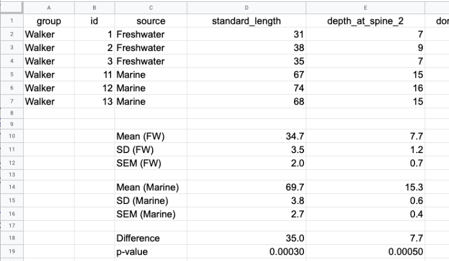

Using the spreadsheet organization above, for each variable, both raw and length-standardized, compute

1. Mean: mean of each group
2. SD: sample standard deviation of each group
3. SEM: standard error of the mean of each group. There is no function for this. Use the formula: $SEM = \frac{SD}{\sqrt(n)}$ where $n$ is the sample size (the number of fish in the group)
4. Difference: the difference in means in the direction $marine - freshwater$ between groups
5. P-value: the p-value for a t-test for the difference in means. The p-value is returned with the t.test function. The function is:

t.test(Range_A, Range_B, 2, 2)

Each of the four items in the parentheses is an **argument**. The first two arguments specify the cell ranges for the two groups to compare (freshwater and marine). The third arguement specifies the “tail” of the test – we are using a “two-tail” t-test. The fourth argument specifies the type of t-test. We want to use the equal variance version, so use “2” for this. See the [t-test entry](https://support.google.com/docs/answer/6055837?hl=en) for more information.

# Descriptive statistics II: correlations

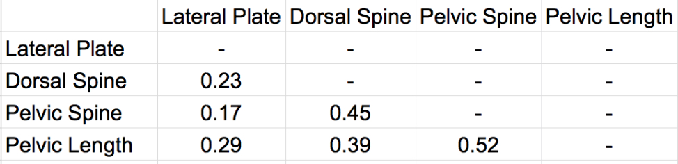

For the freshwater group ONLY, compute the correlations between (1) lateral plate count, (2) standardized dorsal spine length, (3) standardized pelvic spine length, and (4) standardized pelvic length. This should be 6 correlations arranged in a **correlation matrix** that should look like the figure above. Use the correlation function in Google sheets.

# Plot the results

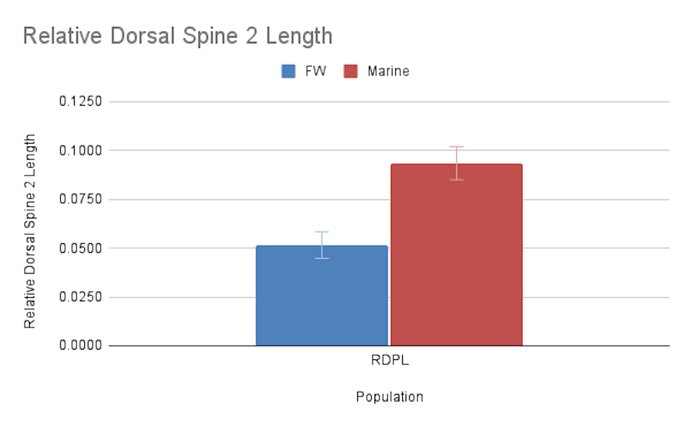

## How to bar plot

1. For each measure to plot, create a table like that below
- the second column is the mean of the measure
- the third column is 2 x SEM of the measure
2. Highlight the first two columns only
3. Insert > Chart (the default should be a column chart)
4. Click the three dots in the upper right of the chart to edit
5. Click “Switch rows/Columns” under Series
6. Click the Customize tab in the edit chart window
7. Click Series
8. Click the “Apply to All Series” pop up menu and choose freshwater
9. Click the Error Bars Box
10. Click the popup menu with “percent” as the item, choose “constant”
11. Add the 2 x SEM value manually
12. Repeat for the marine fish

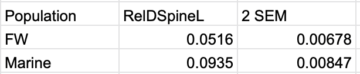

## What to bar plot

1. Add a bar-and-error plot for lateral plate count
2. Add a bar-and-error plot for length-standardized 2nd dorsal spine length
3. Add a bar-and-error plot for length-standardized pelvic spine length
4. Add a bar-and-error plot for length-standardized body depth

The error should be two standard errors.

# Report

# Statistics summary

We will **better know data analysis** next week, but here is a quick summary

The **sample standard deviation** is a measure of variability in a sample. This variability results from true biological variation AND from measurement error. The standard deviation is a kind of average, so it is not related to sample size.

The **standard error of the mean** is a measure of the precision of the estimate of the mean. The standard error decreases as the sample size increases. The standard error increases as noise (standard deviation) increases.

A **95% confidence interval** is an interval that has 95% probability of containing the true mean. It is roughly equivalent to the mean +/- 2 standard errors.

A **t-test** is a test of the difference between the means of two samples. The *t*-test returns a *p*-value.

The **p-value** is the probability of sampling from the null distribution and observing a difference in means as or more extreme than the difference you observed between the two samples. **Sampling from the null distribution** means sampling $n \times 2$ values from a normal distribution, randomly assigning half of these to group $A$, half to group $B$, and then computing the difference $\bar{B} - \bar{A}$.

A **bar plot** is used to show the means or counts or frequencies for different groups. The $X$ axis is categorical and contains the groups. The $Y$ axis is the continuous mean or count or frequency. The base of each bar is at zero. The top of each bar is a the group mean. Most statistics communications experts agree that in general dot plots or box plots are more effective than bar plots.

Most often, bars are augmented with an error interval. A 1-SE interval is the most common and a 1SD interval is the next most common. A 2-SD or 2-SE interval or a confidence interval is a better choice. Which should you use? SD intervals highlight variability. SE/Confidence Intervals highlight precision. Which do you want to communicate? If I want to show that it is really easy to tell marine stickleback from lake stickleback by comparing lateral plate count, I would show the mean +/- 2 SD, since this interval will include 95% of the points in each group. The intervals will not overlap, indicating that the two groups differ completely for this trait. If I want to show visually that the marine stickleback is, on average, relatively deeper (body depth/SL) than a freshwater fish, I would use +/- 2SE; The difference in means is a measure of the “effect” (of evolution in different habitat types on relative body depth) and the less the intervals overlap the more confidence we have in this conclusion.